# Lab 5

## Exercise 1. Finish the Data Visualization tutorial and add it your GitPage web site.

```r
#Downloading data/Getting started.
library(tidyverse)
download.file("http://r-bio.github.io/data/surveys_complete.csv",
              "surveys_complete.csv")

surveys_complete <- read_csv(file = "surveys_complete.csv")
```

## Replace the box plot with a violin plot.

```r
surveys_weight <- surveys_complete %>%
  filter(!is.na(weight))
```

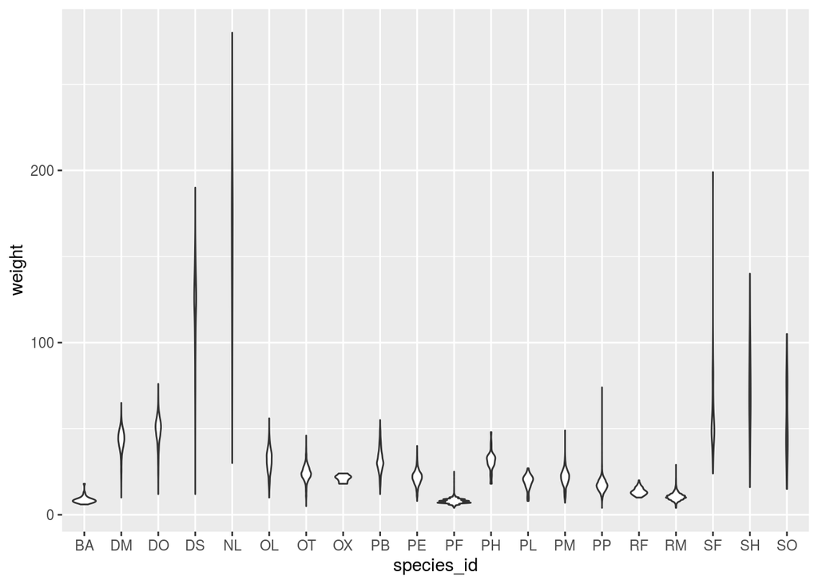

```r
ggplot(data = surveys_weight, mapping = aes(x = species_id, y = weight)) +
    geom_violin()
```

## Represent the weight on the log10 scale.

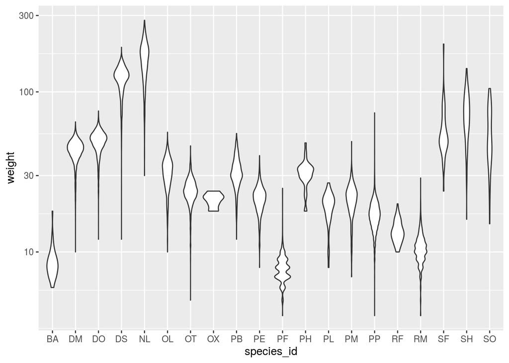

```r
ggplot(data = surveys_weight, mapping = aes(x = species_id, y = weight)) +
    geom_violin() +
  scale_y_log10()
```

## Create a boxplot for hindfoot_length, then overlay the boxplot layer on a jitter layer to show actual measurements.

```r
surveys_ggplot_2 <- surveys_complete %>%
  filter(!is.na(hindfoot_length))
```

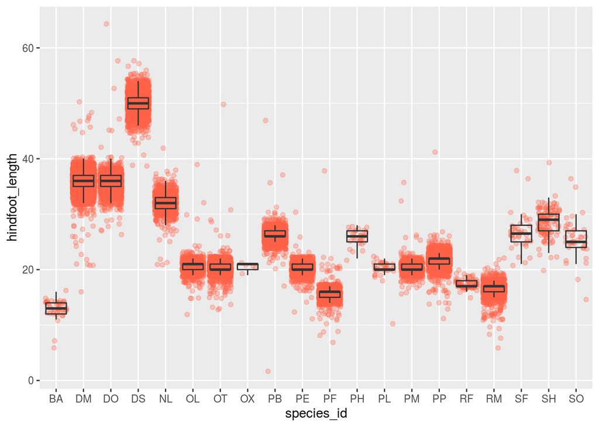

```r
ggplot(data = surveys_ggplot_2, mapping = aes(x = species_id, y = hindfoot_length)) +
  geom_jitter(alpha = 0.3, color = "tomato") +
   geom_boxplot(alpha = 0)
```

## Add color to the data points on your boxplot according to the plot from which the sample was taken (plot_id).

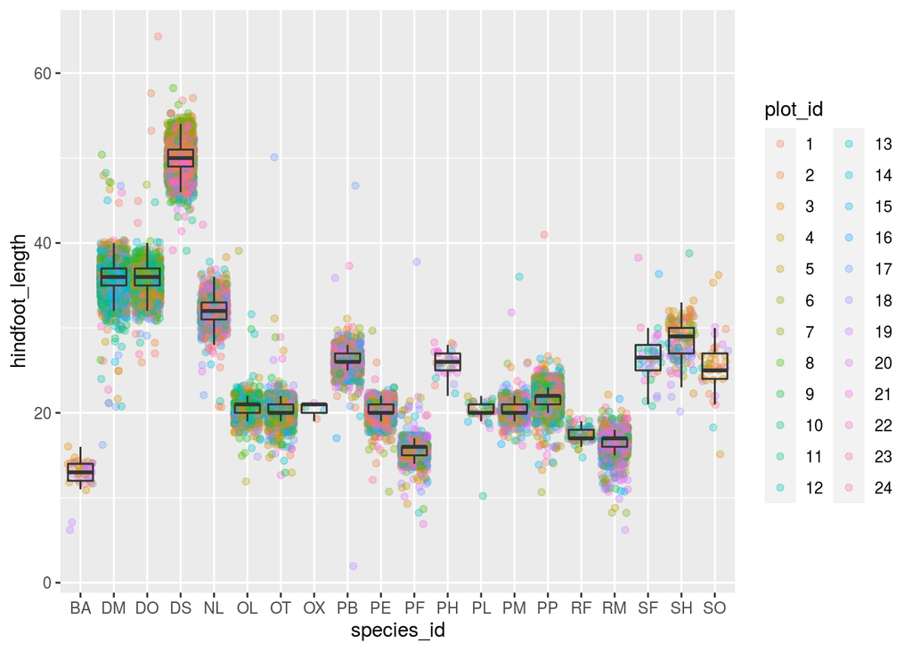

```r
surveys_ggplot_2 <- mutate_at(surveys_ggplot_2, vars(plot_id), as.factor)
ggplot(data = surveys_ggplot_2, mapping = aes(x = species_id, y = hindfoot_length)) +
  geom_jitter(alpha = 0.3, aes(color = plot_id)) +
   geom_boxplot(alpha = 0)
```

## Use what you just learned to create a plot that depicts how the average weight of each species changes through the years.

```r
yearly_weight <- surveys_weight %>%
  group_by(year, species_id) %>%
  summarize(mean_weight = mean(weight))
```

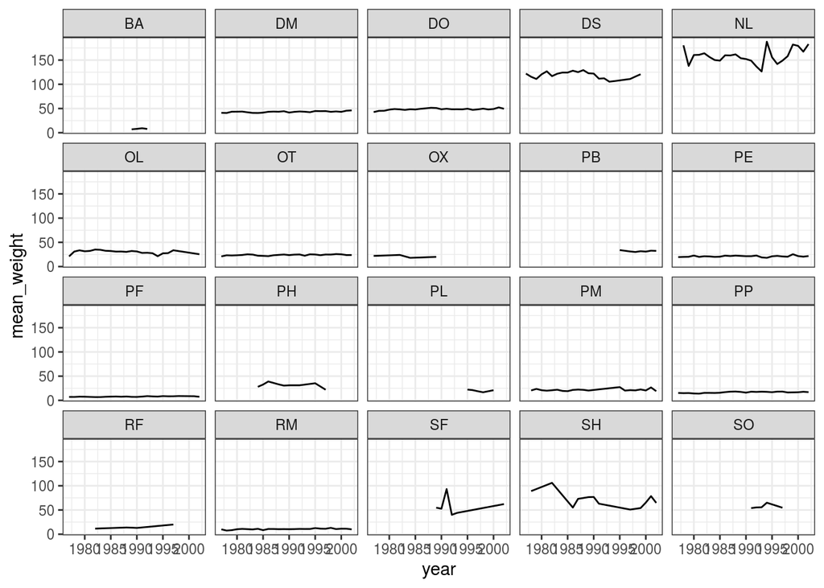

```r
ggplot(data = yearly_weight, aes(x = year, y = mean_weight)) +
     geom_line() +
  facet_wrap(facets = vars(species_id)) +
  theme_bw()
```

## Improve one of the plots generated in this exercise.

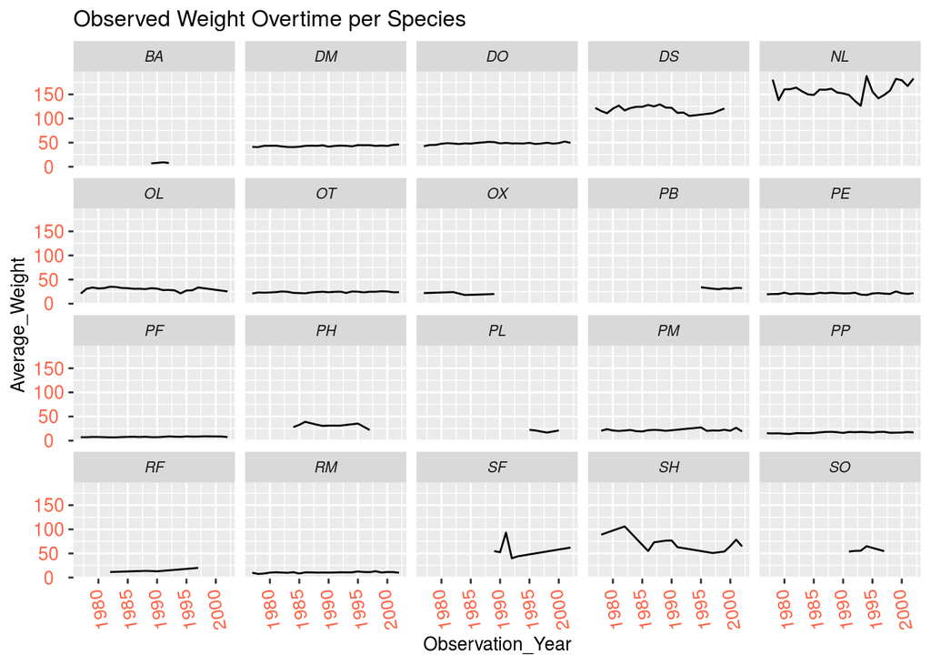

```r
ggplot(data = yearly_weight, aes(x = year, y = mean_weight)) +
  geom_line() +
  facet_wrap(facets = vars(species_id)) +
  labs(title = "Observed Weight Overtime per Species",
        x = "Observation_Year",
        y = "Average_Weight") +
  theme(axis.text.x = element_text(
        colour = "tomato", size = 10, angle = 100, hjust = 0.5, vjust = 0.5),
        axis.text.y = element_text(colour = "tomato", size = 10, angle = 0, hjust = 0.5, vjust = 0.5),
        strip.text = element_text(face = "italic"),
        text = element_text(size = 10))
```

## Exercise 2a. Revise the above example for joining tables using 6/13/2020 and 9/13/2020.

```r
Confirmed_State_6_13 <-   read_csv(url("https://raw.githubusercontent.com/CSSEGISandData/COVID-19/master/csse_covid_19_data/csse_covid_19_daily_reports/06-13-2020.csv")) %>%
  filter (Country_Region == "US") %>%
  group_by(Province_State, Country_Region) %>%
  summarise(Confirmed = sum(Confirmed))
Confirmed_State_9_13 <-   read_csv(url("https://raw.githubusercontent.com/CSSEGISandData/COVID-19/master/csse_covid_19_data/csse_covid_19_daily_reports/09-13-2020.csv")) %>%
  filter (Country_Region == "US") %>%
  group_by(Province_State, Country_Region) %>%
  summarise(Confirmed = sum(Confirmed))
Confirmed_State_6_13 <- Confirmed_State_6_13 %>%
  filter(Province_State != "Recovered")
```

```r
Confirmed_State_9_13 <- Confirmed_State_9_13 %>%
  filter(Province_State != "Recovered")
```

```r
Confirmed_State_6_13 <- Confirmed_State_6_13 %>%
  filter(Country_Region != "Recovered")
```

```r
Confirmed_State_9_13 <- Confirmed_State_6_13 %>%
  filter(Country_Region != "Recovered")
```

```r
#Joining
Confirmed_State_6_13_9_13_joined <- full_join(Confirmed_State_6_13,
      Confirmed_State_9_13, by =c("Province_State"))
head(Confirmed_State_6_13_9_13_joined)
```

| Province_State | Country_Region.x | Confirmed.x | Country_Region.y | Confirmed.y |
| --- | --- | --- | --- | --- |
| Alabama | US | 24601 | US | 24601 |
| Alaska | US | 653 | US | 653 |
| Arizona | US | 34660 | US | 34660 |
| Arkansas | US | 12095 | US | 12095 |
| California | US | 150018 | US | 150018 |
| Colorado | US | 29002 | US | 29002 |

```r
#Rearranging columns
Confirmed_State_6_13_9_13_joined <- full_join(Confirmed_State_6_13,
      Confirmed_State_9_13, by = c("Province_State")) %>%
      rename(Confirmed_6_13_2020 = "Confirmed.x", Confirmed_9_13_2020 = "Confirmed.y") %>%
      select(-Country_Region.x, -Country_Region.y) %>%
      replace_na(list(Confirmed_6_13_2020 = 0))
head(Confirmed_State_6_13_9_13_joined)
```

| Province_State | Confirmed_6_13_2020 | Confirmed_9_13_2020 |
| --- | --- | --- |
| Alabama | 24601 | 24601 |
| Alaska | 653 | 653 |
| Arizona | 34660 | 34660 |
| Arkansas | 12095 | 12095 |
| California | 150018 | 150018 |
| Colorado | 29002 | 29002 |

```r
Confirmed_State_6_13_9_13_joined_long <- Confirmed_State_6_13_9_13_joined %>%
  pivot_longer(-c(Province_State), names_to = "Date", values_to = "Confirmed")
```

## Exercise 2b. Plot the data as a bar plot. Make sure your graph looks nice in the report by adjusting the height in the R code chunk header.

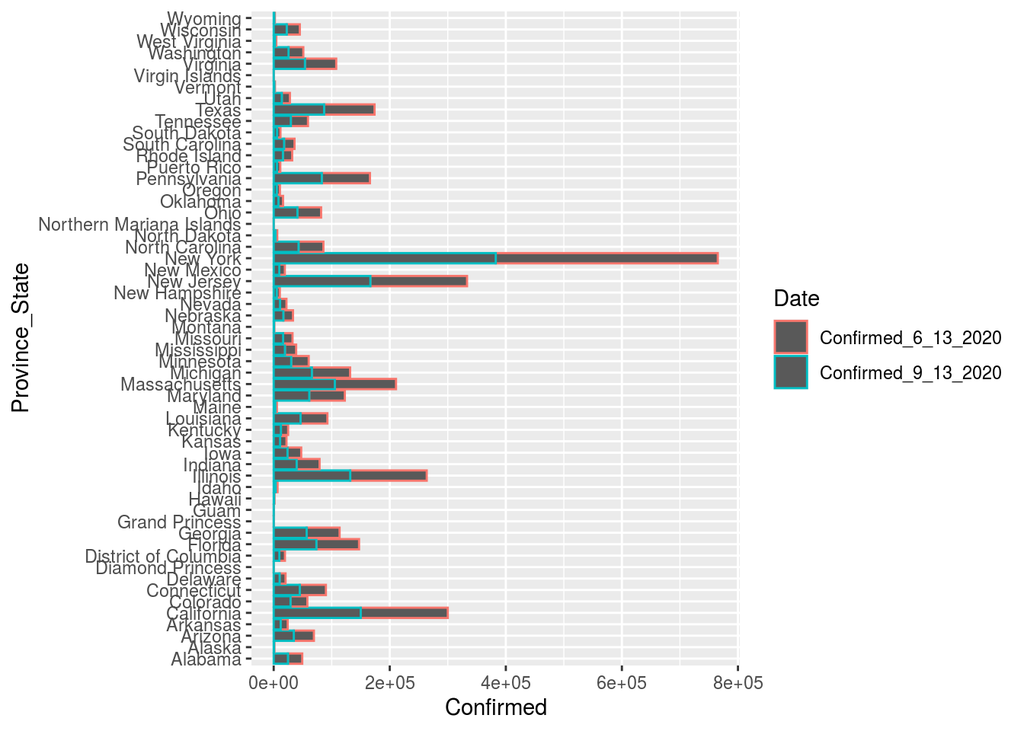

```r
ggplot(data = Confirmed_State_6_13_9_13_joined_long, aes(y = Province_State, x = Confirmed)) +
  geom_bar(stat='identity', aes(color = Date))
```

## Exercise 3. Add more informative x and y labels and a title to the above graph in Ex2.

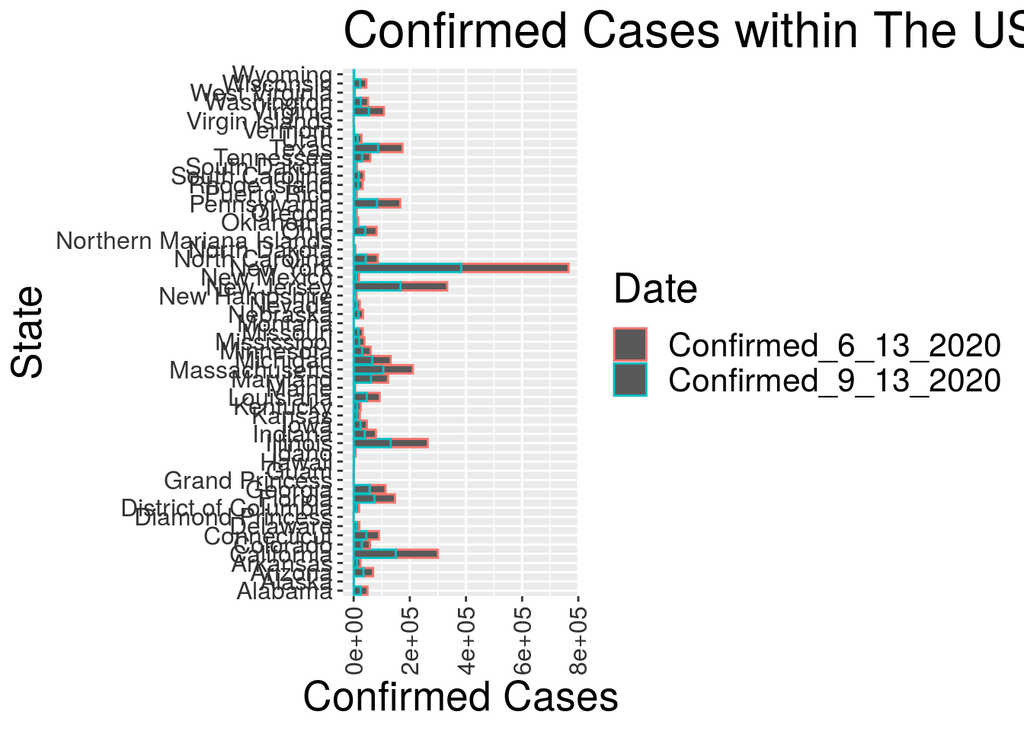

```r
ggplot(data = Confirmed_State_6_13_9_13_joined_long, aes(y = Province_State, x = Confirmed)) +
    labs(title = "Confirmed Cases within The USA",
        y = "State",
        x = "Confirmed Cases") +
  theme(
    axis.text.x = element_text(colour = "grey20", size = 12, angle = 90, hjust = 0.5, vjust = 0.5),
    axis.text.y = element_text(colour = "grey20", size = 12),
    strip.text = element_text(face = "italic"),
    text = element_text(size = 20)) +
  geom_bar(stat='identity', aes(color = Date))
```

## Exercise 4. Using the time series data, make a plot of the total number of confirmed cases & deaths, per day, worldwide.

```r
#Downloading the data (Confirmed)
download.file(url="https://raw.githubusercontent.com/CSSEGISandData/COVID-19/master/csse_covid_19_data/csse_covid_19_time_series/time_series_covid19_confirmed_global.csv", destfile = "data/time_series_covid19_confirmed_global.csv")

time_series_confirmed <- read_csv("data/time_series_covid19_confirmed_global.csv") %>%
  rename(Province_State = "Province/State", Country_Region = "Country/Region")
#Making it long (Confirmed)
time_series_confirmed_long <- time_series_confirmed %>%
               pivot_longer(-c(Province_State, Country_Region, Lat, Long), names_to = "Date", values_to = "Confirmed")
```

```r
#Downloading the data (Deaths)
download.file(url="https://raw.githubusercontent.com/CSSEGISandData/COVID-19/master/csse_covid_19_data/csse_covid_19_time_series/time_series_covid19_deaths_global.csv", destfile = "data/time_series_covid19_deaths_global.csv")

time_series_deaths <- read_csv("data/time_series_covid19_deaths_global.csv") %>%
  rename(Province_State = "Province/State", Country_Region = "Country/Region")
#Making it long (Deaths)
time_series_deaths_long <- time_series_deaths %>%
               pivot_longer(-c(Province_State, Country_Region, Lat, Long), names_to = "Date", values_to = "Deaths")
```

```r
#Let's combine confirmed & deaths
time_series_confirmed_long <- time_series_confirmed_long %>%
  unite(Key, Province_State, Country_Region, Date, sep = ".", remove = FALSE)

time_series_deaths_long <- time_series_deaths_long %>%
  unite(Key, Province_State, Country_Region, Date, sep = ".") %>%
  select(Key, Deaths)

time_series_long_joined <- full_join(time_series_confirmed_long,
              time_series_deaths_long, by = c("Key")) %>%
              select(-Key)
```

```r
head(time_series_long_joined)
```

| Province_State | Country_Region | Lat | Long | Date | Confirmed | Deaths |
| --- | --- | --- | --- | --- | --- | --- |
| NA | Afghanistan | 33.93911 | 67.70995 | 1/22/20 | 0 | 0 |
| NA | Afghanistan | 33.93911 | 67.70995 | 1/23/20 | 0 | 0 |
| NA | Afghanistan | 33.93911 | 67.70995 | 1/24/20 | 0 | 0 |
| NA | Afghanistan | 33.93911 | 67.70995 | 1/25/20 | 0 | 0 |
| NA | Afghanistan | 33.93911 | 67.70995 | 1/26/20 | 0 | 0 |
| NA | Afghanistan | 33.93911 | 67.70995 | 1/27/20 | 0 | 0 |

```r
library(lubridate)
time_series_long_joined$Date <- mdy(time_series_long_joined$Date)

time_series_long_joined_counts <- time_series_long_joined %>%
  pivot_longer(-c(Province_State, Country_Region, Lat, Long, Date),
               names_to = "Report_Type", values_to = "Counts")
head(time_series_long_joined_counts)
```

| Province_State | Country_Region | Lat | Long | Date | Report_Type | Counts |
| --- | --- | --- | --- | --- | --- | --- |
| NA | Afghanistan | 33.93911 | 67.70995 | 2020-01-22 | Confirmed | 0 |
| NA | Afghanistan | 33.93911 | 67.70995 | 2020-01-22 | Deaths | 0 |
| NA | Afghanistan | 33.93911 | 67.70995 | 2020-01-23 | Confirmed | 0 |
| NA | Afghanistan | 33.93911 | 67.70995 | 2020-01-23 | Deaths | 0 |
| NA | Afghanistan | 33.93911 | 67.70995 | 2020-01-24 | Confirmed | 0 |
| NA | Afghanistan | 33.93911 | 67.70995 | 2020-01-24 | Deaths | 0 |

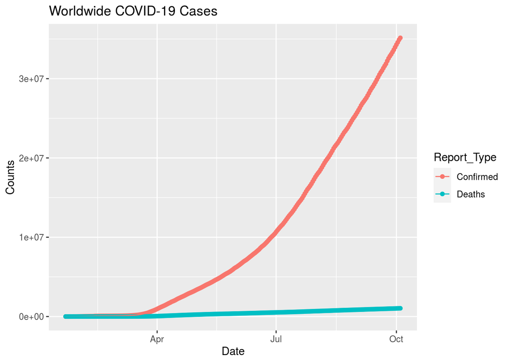

```r
#Make a plot of the total number of confirmed cases & deaths, per day, worldwide
time_series_long_joined_counts %>%
  group_by(Report_Type, Date) %>%
  summarise(Counts = sum(Counts)) %>%
    ggplot(aes(x = Date,  y = Counts, fill = Report_Type, color = Report_Type)) +
    geom_point() +
    geom_line() +
    ggtitle("Worldwide COVID-19 Cases")
```

## Exercise 5. Use Mutate to make a new column with deaths/confirmed cases (Hint: this might be best done after joining the tables, but before pivoting longer)

```r
time_series_long_joined_ratio <- time_series_long_joined %>%
  group_by(Country_Region, Date) %>%
  summarise(Total_Confirmed = sum(Confirmed), Total_Deaths = sum(Deaths)) %>%
  mutate(Ratio = Total_Deaths / Total_Confirmed)
head(time_series_long_joined_ratio)
```

| Country_Region | Date | Total_Confirmed | Total_Deaths | Ratio |
| --- | --- | --- | --- | --- |
| Afghanistan | 2020-01-22 | 0 | 0 | NaN |
| Afghanistan | 2020-01-23 | 0 | 0 | NaN |
| Afghanistan | 2020-01-24 | 0 | 0 | NaN |
| Afghanistan | 2020-01-25 | 0 | 0 | NaN |
| Afghanistan | 2020-01-26 | 0 | 0 | NaN |
| Afghanistan | 2020-01-27 | 0 | 0 | NaN |

## Exercise 6. Plot US deaths/confirmed cases per day.

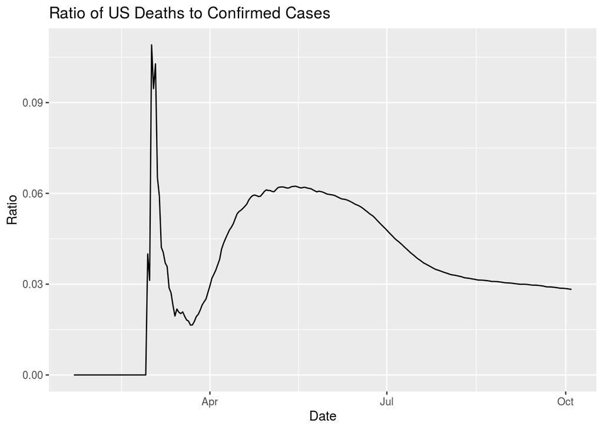

```r
time_series_long_joined_ratio %>%
    filter (Country_Region == "US") %>%
    ggplot(aes(x = Date,  y = Ratio)) +
    geom_line() +
    ggtitle("Ratio of US Deaths to Confirmed Cases")
```

## Exercise 7. Make a single graph with the times series data with the 10 countries with the hightest death total.

```r
#Highest death total
time_series_long_total_deaths <- time_series_long_joined_ratio %>%
  group_by(Country_Region) %>%
  summarise(Deaths = sum(Total_Deaths)) %>%
  arrange(desc(Deaths)) %>%
  slice(1:10)
library(DT)

datatable(time_series_long_total_deaths)
```

|  | Country_Region | Deaths |
| --- | --- | --- |
| 1 | US | 23753609 |
| 2 | Brazil | 12231901 |
| 3 | United Kingdom | 6662676 |
| 4 | Italy | 6157081 |
| 5 | Mexico | 6126174 |
| 6 | India | 5717206 |
| 7 | France | 5175708 |
| 8 | Spain | 5072443 |
| 9 | Peru | 2540488 |
| 10 | Iran | 2512704 |

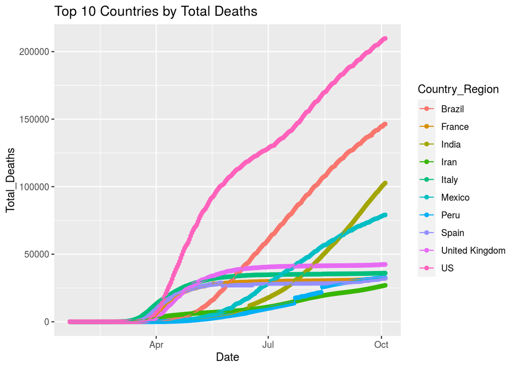

```r
#Manually select theses countries for the plot
time_series_long_joined_ratio %>%
    filter(Country_Region %in% c("US", "Brazil", "United Kingdom", "Italy", "Mexico", "France", "Spain", "India", "Iran", "Peru")) %>%
    ggplot(aes(x = Date,  y = Total_Deaths, fill = Country_Region, color = Country_Region)) +
    geom_point() +
    geom_line() +
    ggtitle("Top 10 Countries by Total Deaths")
```

## Exercise 8. Using Facet_Wraps make a graph from the times series data with the 10 countries with the hightest death total. Format the table to look nice in the report by changing the number of rows in your graph and/or adjusting the height in the R code chunk header.

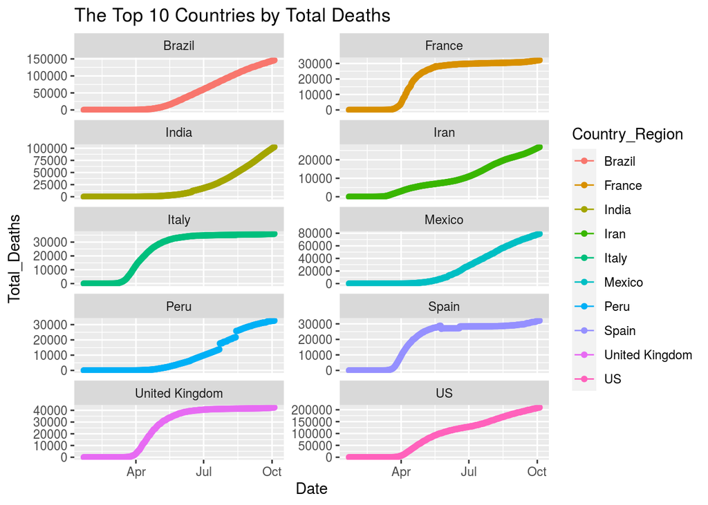

```r
time_series_long_joined_ratio %>%
    filter(Country_Region %in% c("US", "Brazil", "United Kingdom", "Italy", "Mexico", "France", "Spain", "India", "Iran", "Peru")) %>%
    ggplot(aes(x = Date,  y = Total_Deaths, fill = Country_Region, color = Country_Region)) +
    geom_point() +
    geom_line() +
    ggtitle("The Top 10 Countries by Total Deaths") +
  facet_wrap(~Country_Region, ncol=2, scales="free_y")
```

## Exercise 9. Using Facet_Wraps make a graph from the times series data for confirmed cases for all US states and territories.

```r
download.file(url="https://raw.githubusercontent.com/CSSEGISandData/COVID-19/master/csse_covid_19_data/csse_covid_19_time_series/time_series_covid19_confirmed_US.csv", destfile = "data/time_series_covid19_confirmed_US.csv")

time_series_covid19_confirmed_US <- read.csv("data/time_series_covid19_confirmed_US.csv")
```

```r
time_series_covid19_confirmed_US_totals <- time_series_covid19_confirmed_US %>%
  select(-c(UID,iso2,iso3,code3,FIPS,Lat,Long_,Combined_Key,Admin2,Country_Region)) %>%
  group_by(Province_State) %>%
  summarise_each(funs(sum))
#Remove x from the dates
time_series_covid19_confirmed_US_totals <- time_series_covid19_confirmed_US_totals %>% rename_at(vars(starts_with("X")), funs(str_remove(., "X")))
```

```r
#Pivot
confirmed_US_totals_long <- time_series_covid19_confirmed_US_totals %>%
  pivot_longer(-c(Province_State),
               names_to = "Date",
               values_to = "Confirmed")
```

```r
#Improve dates
confirmed_US_totals_long$Date <- as.Date(confirmed_US_totals_long$Date, format = "%m.%d.%y")
```

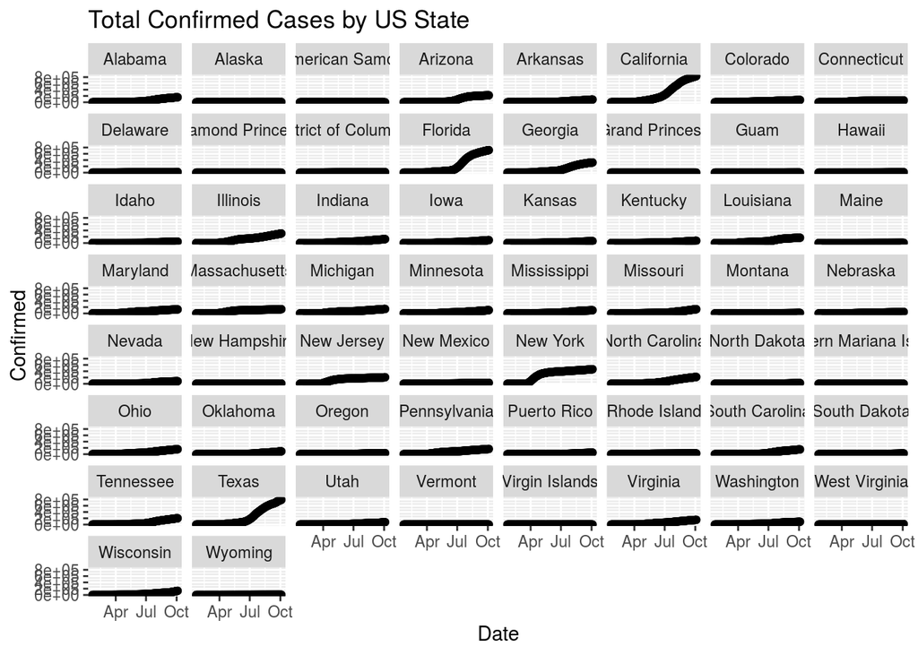

```r
#Graph
confirmed_US_totals_long %>%
ggplot(aes(x = Date,  y = Confirmed)) +
    geom_point() +
    geom_line() +
    ggtitle("Total Confirmed Cases by US State") +
  facet_wrap(~Province_State)
```

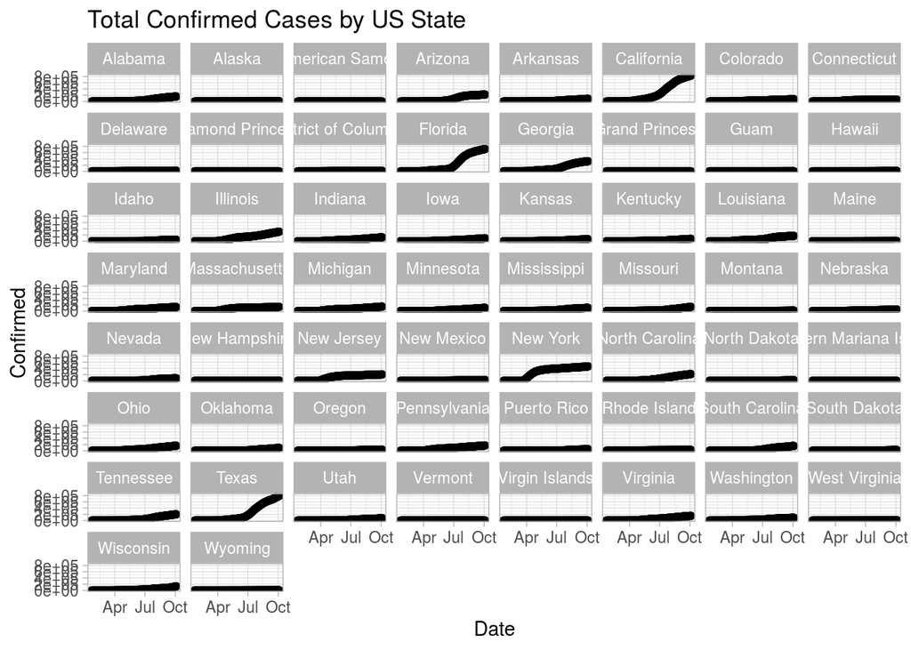

```r
confirmed_US_totals_long %>%
ggplot(aes(x = Date,  y = Confirmed)) +
    geom_point() +
    geom_line() +
    ggtitle("Total Confirmed Cases by US State") +
  facet_wrap(~Province_State) +
  theme_light()
```